[figure not shown]

# PyData London News July 2023

### 75th Meetup, hosted by Man Group

### @PyDataLondon

# PyData Code of Conduct

### https://pydata.org/code-of-conduct/

[interactive chart not shown]

# NumFOCUS

- US-based charity in support of open-source scientific computing
- Financial and admin support for many open-source projects
- Support for many community events
- https://numfocus.org

[interactive chart not shown]

# PyData

- Educational program by NumFOCUS
- A global community
- 219 groups across 76 countries world-wide (+3 new countries in 2023!) 🇳🇿🇳🇿🇳🇿
- 213,000+ users world-wide (+23,000 per year!)
- https://www.meetup.com/pro/pydata/

[figure not shown]

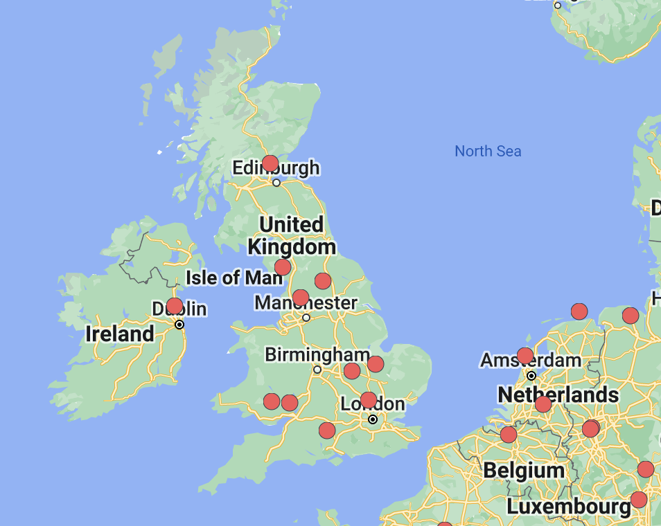

# PyData London

- 11,800+ members (Approx +100 members/month, we can do better! Tell a friend! Submit a talk! Need more ⚡)
- Monthly meetup + annual conference
- All run by volunteers
- https://london.pydata.org/
- Propose a Talk: https://london.pydata.org/submit-a-talk/

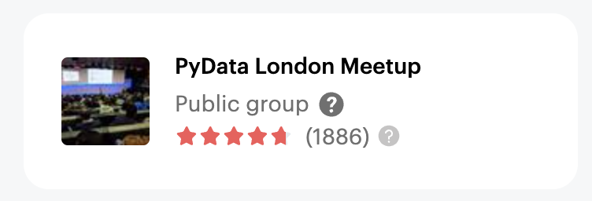

[figure not shown]

## Man Group

1. The world's largest publicly traded hedge fund company with $143 billion in funds under management in 2022.
2. 100 open positions in both tech and research.
3. Sponsors **PyData London** ❤️❤️❤️

# Upcoming Conferences

### Courtesy of https://pythondeadlin.es/

#### 🇺🇸 July 10 2023 - SciPy 2023 (Austin, Texas)

#### 🇨🇿 July 17-23 2023 - EuroPython 2023 (Prague, Czechia + REMOTE)

#### 🇳🇱 Sep 14-16 2023 - PyData Amsterdam 2023

#### 🇬🇧 Sep 22-25 2023 - PyCon UK 2023

#### 🇹🇿 Nov 6-11 2023 - DjangoCon Africa 2023 (Zanzibar, Tanzania) 🚨 CFP deadline 13th July 🚨

#### 🇮🇪 Nov 12-13 2023 - PyCon Ireland 2023 🚨 CFP deadline 17th July 🚨

#### 🇮🇱 Nov 14 2023 - PyData Tel Aviv 2023 🚨 CFP deadline 14th July 🚨

[interactive chart not shown]

# Upcoming Local Meetups & Events

#### 3rd - 9th July 2023 = London Data Week

# PyData London 2023 - June 2nd-4th

#### https://pydata.org/london2023/

#### Venue: the Leonardo Royal Hotel near Tower Bridge

#### Tutorials on Friday

#### Keynotes, talks and more on Saturday-Sunday

#### Free childcare support

#### Diversity scholarships

#### All proceeds benefit NumFOCUS

## https://pydata.org/london2023/

[figure not shown]

# Announcing PyData London 2024...

[figure not shown]

# ✨ PyData London 2024 🎉

[figure not shown]

# Tonight's Schedule

#### 18:30 Doors open

#### 19:00 Talks start ⬅️ **YOU ARE HERE**

#### 19:15 Talk #1 + Q&A

#### 19:45 Break 🥂

#### 20:00 Talk #2 + Q&A

#### 20:30 ⚡ Lightning Talks ⚡ + 📣 Community Announcements 📣

#### 20:45 to 21:00 We're done 🔜 The Banker 🍻

### 1️⃣ Evaluating Distributional Forecasts - Leonidas Tsaprounis

In this talk we will focus on the metrics you can use to evaluate distributional forecasts. Distributional forecasts can be in the form of monte-carlo samples of future paths or analytical distributions and they aim to describe the full distribution for a forecasted time point. Using simple implementations with numpy and scipy we will go through the properties of different metrics like the Continuous Rank Probability Score (CRPS) and the Log Score and use them to pick the best forecasting algorithm using cross-validation.

### 2️⃣ How To Build Your Own Private ChatGPT Using Streamlit, LangChain & Vicuna - John Sandall

Your garden variety Large Language Model (LLM) is pretty great but comes with some downsides: no information after September 2021, and potentially insecure if you want to leverage internal documents and sensitive data, so let's build our own Vicuna-powered “ChatGPT”!

## ⚡ Lightning Talks ⚡

### ⚡1️⃣ Open Source is Technically Illegal – Casper da Costa-Luis

You are probably breaking the law.

### ⚡2️⃣ London Data Week – Jennifer Ding

London Data Week 2023 (https://www.londondataweek.org/) runs from 3rd-9th July, a citywide festival about data to learn, create, discuss, and explore how to use data to shape our city for the better. Find out what's happening across London, from Turing Institute's data cabaret to citizen science.

## 🕊️ Tweet #pydatalondon and @pydatalondon 🦆